# 🚩 Conceitos Fundamentais

### Diferença entre População e Amostra

- População = totalidade dos elementos que compõem um determinado conjunto
- Amostra = uma parte dos elementos que compõem a população

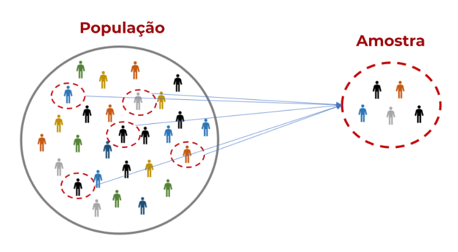

### Parâmetros Populacionais e Estatísticas amostrais

Parâmetros são valores numéricos que caracterizam uma população, enquanto estatísticas são valores numéricos que caracterizam uma amostra retirada dessa população

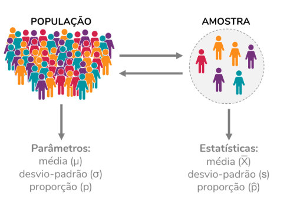

### Elementos e Variáveis

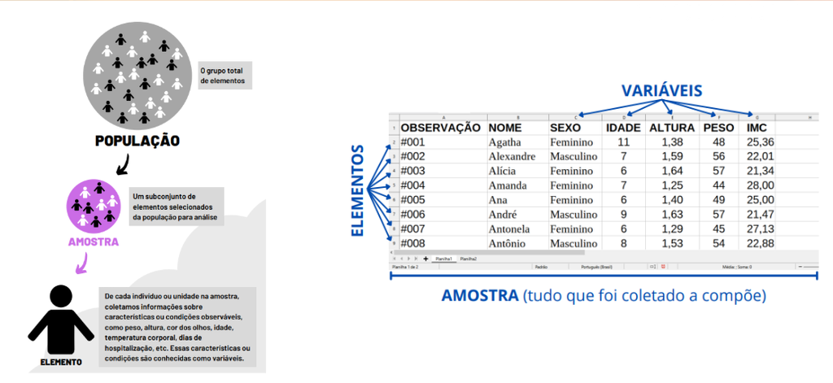

**Exemplos**

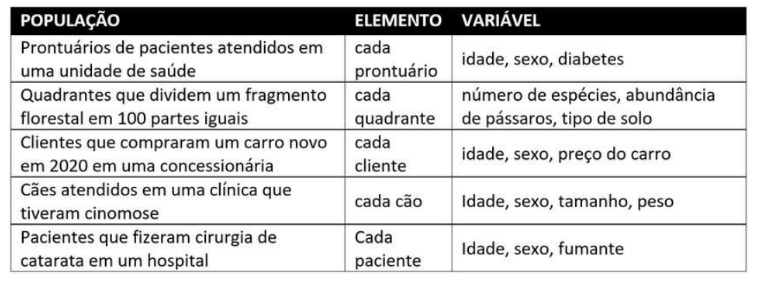

### Diferença entre estatística descritiva e inferencial

Na análise descritiva, o foco está em descrever e resumir os dados por meio de medidas numéricas e representações gráficas. Já na análise inferencial, o objetivo é tirar conclusões gerais sobre a população a partir de amostras representativas, utilizando técnicas como estimativas e testes de hipóteses.

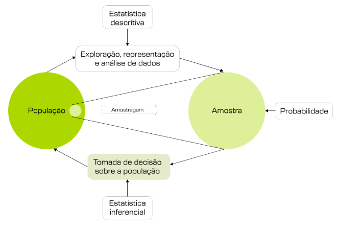

**Por que amostrar?**

- Populações infinitas: O estudo não chegaria nunca ao fim. Não é possível investigar todos os elementos da população.
- Testes destrutivos: Estudos onde os elementos avaliados são totalmente consumidos ou destruídos. Exemplo: testes de vida útil, testes de segurança contra colisões em automóveis.
- Resultados rápidos: Pesquisas que precisam de mais agilidade na divulgação. Exemplo: pesquisas de opinião, pesquisas que envolvam problemas de saúde pública. fazer uma pesquisa de opinião de eleição com a população toda seria a própria eleição
- Custos elevados: Quando a população é finita mas muito numerosa, o custo de um censo pode tornar o processo inviável.

**Exemplo**

- Quando analisamos a satisfação dos pacientes com o atendimento assistencial dos profissionais de uma equipe, calculamos a média das notas de satisfação, a dispersão (desvio padrão) e verificamos a distribuição das notas em gráficos. Isso nos ajuda a entender o perfil geral de satisfação sem fazer generalizações sobre outros grupos.
- Contudo seria impraticável entrevistar todos os pacientes para saber sua satisfação. E nem seria preciso. Podemos entrevistar uma amostra representativa e, a partir dessa amostra, usar inferência para estimar o nível de satisfação de toda a base de pacientes.

# 📈 Estimador

### O que é uma estimativa

Um estimador é uma estatística (ou qualquer método) usado para estimar um parâmetro populacional desconhecido com base em informações obtidas a partir de uma amostra. Em outras palavras, é uma regra ou fórmula que combina os valores observados nos dados amostrais para fornecer uma estimativa do parâmetro de interesse na população.

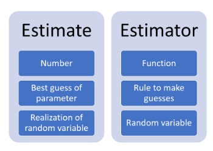

### Tipos de estimativas

- Estimativas pontuais representam valores discretos (um único ponto) e os estimativas de intervalo representam um intervalo de valores (um intervalo de valores).
- As Estimativas intervalares estão relacionadas a intervalos de confiança porque representam um intervalo de valores nos quais é provável que um estimador pontual apropriado esteja contido.

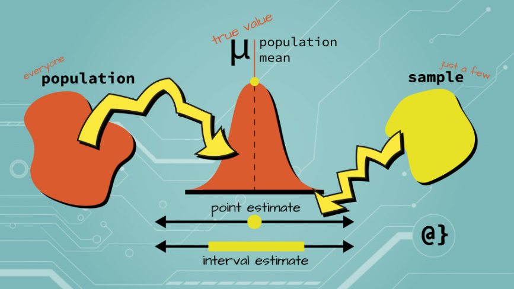

### Um bom estimador estima bem

- **Imparcialidade**: um estimador é considerado imparcial o valor observado é igual ao valor esperado. Caso contrário, é um estimador tendencioso ou enviesado.
- **Consistência**: um estimador é considerado consistente desde que sua precisão sofra aumento quando a amostra se torna maior, ou seja, o erro entre o valor esperado e o valor observado diminui à medida que o tamanho da amostra aumenta.
- **Eficiência**: um estimador é considerado eficiente se tiver a menor variância em comparação com todos os estimadores consistentes e imparciais.
- **Suficiência**: um estimador é considerado suficiente se contém todas as informações da amostra.

# 🧪Amostra

### Amostragem

Amostragem é o procedimento definido para selecionar uma amostra.

Essa seleção pode ser feita de modo probabilística, nas quais existe aleatoriedade Cada membro da população deve ter chances iguais de ser escolhido para o estudo neste tipo de amostragem), ou de mdo não probabilística, nas quais a seleção de sujeitos é realizada de forma não aleatória.

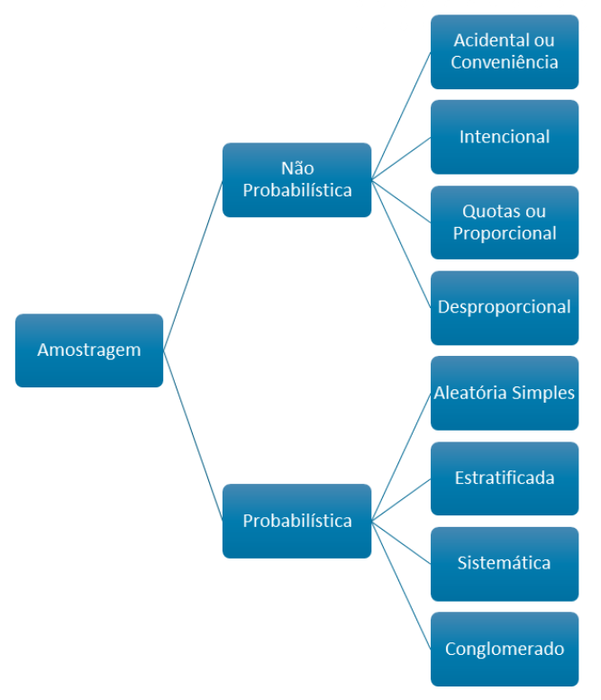

A amostragem é uma etapa fundamental ao trabalhar com dados, especialmente quando queremos generalizar conclusões para a população inteira. Muitas vezes, esse passo é negligenciado, o que pode resultar em viés e erros na análise. Escolher a amostra correta ajuda a evitar vieses e melhora a eficiência dos resultados.

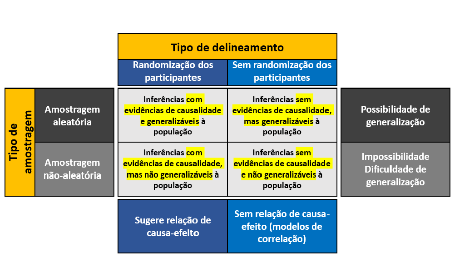

### Erro amostral

Devemos ter em mente que uma amostra nunca representará perfeitamente uma população.

Assim, teremos naturalmente um Erro Amostral, que é representado pela diferença entre o resultado amostral e o verdadeiro valor populacional.

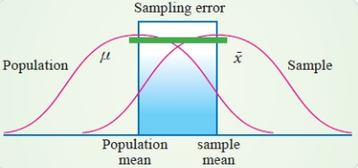

A fórmula de erro amostral sugere que, à medida que o tamanho da amostra (Tamanho da Amostra) aumenta, o denominador da expressão aumenta, o que, por sua vez, diminui o erro amostral. Isso significa que, em geral, amostras maiores têm menos probabilidade de resultar em uma estimativa muito distante do verdadeiro valor da população. Entretanto, é importante notar que o ganho em precisão diminui à medida que o tamanho da amostra aumenta. Em outras palavras, o aumento no tamanho da amostra tem um impacto maior na redução do erro amostral quando a amostra é pequena, mas o mesmo aumento pode ter um impacto menor quando a amostra já é grande. Portanto, embora seja verdade que, em geral, o erro amostral tende a diminuir com o aumento do tamanho da amostra, é crucial considerar outros fatores, como a variabilidade inerente à população e os objetivos específicos da pesquisa ao determinar o tamanho adequado da amostra

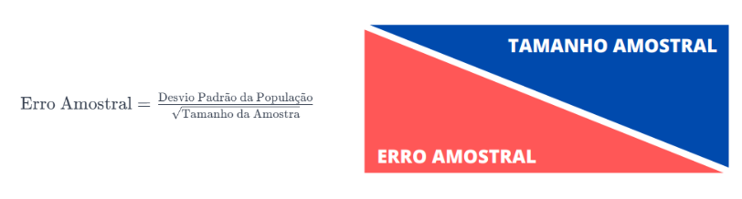

# 🧾Variáveis

### O que é uma variável aleatória

Variável aleatória é uma variável cujo valor é determinado por eventos aleatórios.

Eventos (que são acontecimentos factuais) aleatórios podem ser percebidos por experimentos aleatórios, que são processos cujo resultado não pode ser previsto com certeza antes da execução. Cada execução do experimento pode resultar em um conjunto diferente de resultados, mesmo sendo repetido sob as mesmas condições.

Exemplos de experimentos aleatórios incluem lançar um dado, jogar uma moeda, medir a temperatura de um ambiente, entre outros.

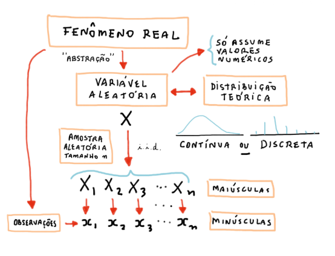

### Contagem de frequências das variáveis aleatórias

Tabelas de frequência são uma forma de organizar dados em uma tabela para mostrar a frequência de ocorrência de cada valor ou intervalo de valores em um conjunto de dados captados, por exemplo, de variáveis aleatórias em experimentos aleatórios.

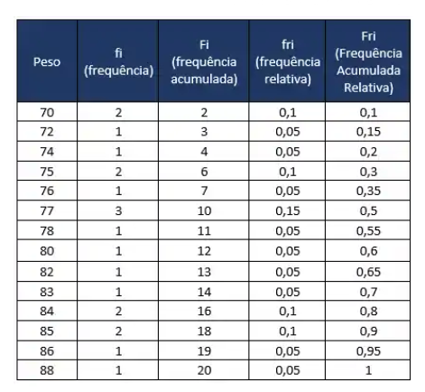

### Relação entre Probabilidade e Frequência Relativa

A probabilidade está intrinsecamente ligada a esses conceitos, pois ela fornece uma medida quantitativa de quão provável é a ocorrência de diferentes valores para a variável aleatória.

A **probabilidade é uma medida teórica que expressa a expectativa** de ocorrência de um evento em um contexto idealizado. A **frequência relativa é uma medida observacional que expressa a proporção real** de ocorrências do evento em um conjunto de dados coletados

### Lei dos Grandes Números

De acordo com a Lei dos Grandes Números, à medida que o tamanho da amostra aumenta, a frequência relativa tende a convergir para a probabilidade teórica. Isso significa que, em experimentos repetidos ou com grandes conjuntos de dados, a frequência relativa se aproxima da probabilidade real.

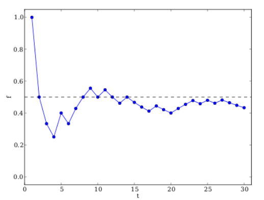